# 上級マクロ経済学

補論 微分と積分の復習

Author

荻巣嘉高

# 1 微分

## 平均変化率と傾き

関数$f(x)$が与えられた時、$x= x_0$から$x=x_1$における関数$f(x)$の平均変化率は、
$$\frac{f(x_1)-f(x_0)}{x_1-x_0}$$
と書くことができる。

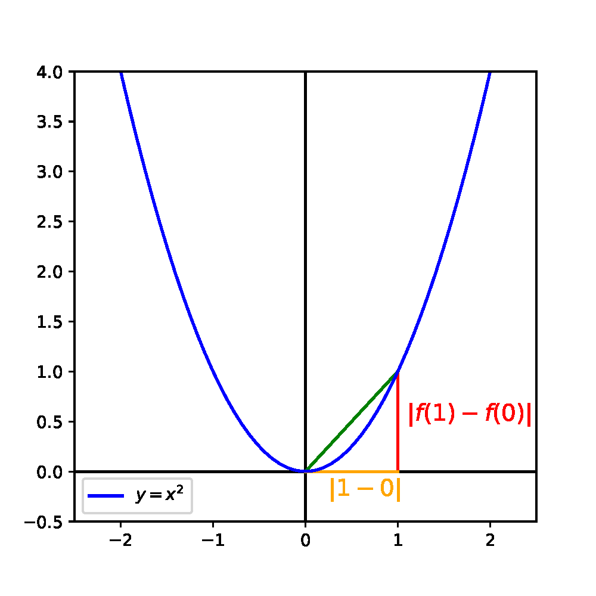

$f(x)=x^2$の例

## いくつもの平均変化率

いま、$f(x)=x^2$におけるいくつかの平均変化率を求めてみよう。 例えば、$x_0=1$、$x_1=2$とすると、
$$\frac{f(2)-f(1)}{2-1} = \frac{2^2 - 1^2}{1} = 3$$
また、$x_0=2$、$x_1=3$とすると、
$$\frac{f(3)-f(2)}{3-2} = \frac{3^2 - 2^2}{1} = 5$$
このように、$x$の差$x_1 - x_0$を同じようにとっても、平均変化率は異なりうることがわかる。

## 平均変化率から微分へ

平均変化率を求める際の、$x_0,x_1$について、
$$\Delta x_0 \equiv x_1 - x_0$$
と定義する。 これを用いて、先の定義式を書き換えると、
$$\frac{f(x_0 + \Delta x_0) - f(x_0)}{\Delta x_0}$$

$\Delta x_0 \to 0$の時、この直線は関数$f(x)$と$x=x_0$の1点で接するとみなせる。

これを、関数$f(x)$の$x=x_0$における **接線**という。

[figure not shown]

## 微分係数

接線の傾きは、平均変化率において、$\Delta x_0 \to 0$としたものなので、
$$\lim_{\Delta x_0 \to 0} \frac{f(x_0+\Delta x_0) - f(x_0)}{\Delta x_0}$$
と書ける。 これを関数$f(x)$の$x=x_0$における**微分係数**と呼び、
$$f'(x_0) \equiv \lim_{\Delta x_0 \to 0} \frac{f(x_0+\Delta x_0) - f(x_0)}{\Delta x_0}$$
と定義する。

## 導関数

$x_0$はどの点でも取れるので、一般に$x$に置き換えられる。 ゆえに、この対応関係は関数とみることができる。

このように、$f'(x)$を$x$の関数として見たものを関数$f(x)$の**導関数**という。 当然導関数も
$$f'(x) \equiv \lim_{\Delta x \to 0} \frac{f(x+\Delta x) - f(x)}{\Delta x}$$
と定義される。

関数$f(x)$からその導関数$f'(x)$を求める作業を$f(x)$を*微分する*という。

- 実用上は導関数を求める公式が存在するため、普通は公式を用いて微分演算を行う。

## 微分の表現

$f(x)$の微分の表し方はいくつかあり、
$$f'(x), \hspace{12pt} \frac{d}{dx} f(x), ~ \frac{d f(x)}{dx}, ~ \frac{d f}{dx} (x), ~ (f(x))'$$
などが代表的である。

## $x^a$の微分

もっとも有名な$x^a$の微分は、次のように公式が与えられている。
$$(x^a)' = a x^{a-1}$$
ここで、$a$は実数である。

## 線形性

微分の演算は、線形性と呼ばれる次の性質が成り立つ。
$$\begin{aligned}
(f(x) + f(y))' &= f'(x) + f'(y), \\
f'(\lambda x) &= \lambda f'(x).
\end{aligned}$$

## 合成関数の微分

合成関数とは、
$$f(g(x))$$
のように、関数の変数としてさらに関数が入っているようなものであった。

**例はこちら**

例えば、
$$f(x) = (x-2)^2$$
という関数は、 $g(x) = x-2$、$h(y) = y^2$としたとき、
$$\begin{aligned}
f(x) &= (x-2)^2 \\
&= \{g(x)\}^2 \\
&= y^2 \hspace{12pt} (y \equiv g(x)) \\
&= h(y) \\
&= h(g(x)) \hspace{12pt} (\because y=g(x))
\end{aligned}$$
という合成関数と見ることができる。

合成関数を微分する際には、次の微分の公式を使うことができる。
$$\{ f(g(x)) \}' = g'(x)f'(g(x))$$

**微分の例はこちら**

$f(x) = (x-2)^2$を微分するとしよう。 $f(x)=h(g(x))$とみると、
$$g'(x) = 1, \hspace{12pt} h'(y) = 2y$$
なので、これらを用いて、
$$\begin{aligned}
f'(x) &= \{ h(g(x)) \} \\
&= g'(x) h'(g(x)) \\
&= 1 \times h'(x-2) \\
&= 2(x-2)
\end{aligned}$$

## 積の微分、商の微分

関数が積の形で表されている場合、次の積の微分公式を用いることができる。
$$\{ f(x) g(x) \}' =f'(x) g(x) + f(x) g'(x)$$

**積の微分の例**

例えば、
$$f(x) = (x+ 3)(x-2)$$
を微分してみよう。いま、$g(x)=x+3$、$h(x)=x-2$とすると、
$$f(x) = g(x) h(x)$$
と書けるので、
$$g'(x) = 1, \hspace{12pt} h'(x) = 1,$$
を用いて、
$$\begin{align*}
f'(x) &= \{g(x) h(x)\} \\
&= g'(x) h(x) + g(x) h'(x) \\
&= 1 \times (x-2) + (x+3) \times 1 \\
&= 2x + 1
\end{align*}$$
と解を得ることができる。

商の形で表される関数、つまり
$$\frac{f(x)}{g(x)} \hspace{12pt} (g(x) \neq 0)$$
となっているような関数を微分すると、
$$\left[ \frac{f(x)}{g(x)} \right]' = \frac{f'(x) g(x) - f(x) g'(x)}{\{ g(x) \}^2}$$
となる。

**商の微分公式の導出**

$$\frac{f(x)}{g(x)} = f(x) \{g(x)\}^{-1}$$
と見ることができる。 すると、$h(y) = y^{-1}$と見て、
$$\frac{f(x)}{g(x)} = f(x) \{g(x)\}^{-1} = f(x) h(g(x))$$
とすることができる。 今この関数を積の微分と合成関数の微分を用いて微分をすると、
$$\begin{aligned}
\left[ \frac{f(x)}{g(x)} \right]' &= \left[ f(x) \{ g(x) \}^{-1} \right]' \\
&= \left[ f(x) h(g(x)) \right]' \\
&= f'(x) h(g(x)) + f(x) \left\{ h(g(x)) \right\}' \\
&= f'(x) h(g(x)) + f(x) \left\{ g'(x) h'(g(x)) \right\} \\
&= f'(x) h(g(x)) + f(x) \left[ g'(x) (-1 \times \{ g(x) \}^{-2}) \right] \hspace{12pt} (\because h'(y) = - y^{-2}) \\
&= \frac{f'(x)}{g(x)} - f(x) g'(x) \{g(x)\}^{-2} \\
&= \frac{f'(x)}{g(x)} - \frac{f(x) g'(x)}{\{g(x)\}^{-2}} \\
\therefore \left[ \frac{f(x)}{g(x)} \right]' &= \frac{f'(x) g(x) - f(x) g'(x)}{\{ g(x) \}^2}
\end{aligned}$$
と計算でき、商の微分公式を得ることができる。

## 指数関数の微分

指数関数とは、
$$f(x) = a^x$$
の形で与えられる関数である。 この指数関数の導関数は次のように与えられる。
$$f'(x) = a^x \log a$$
特に、$a$がネイピア数であるとき、つまり$a=e$のときには、
$$f'(x) = \{ e^x \}' = e^x$$
となる。 $e^x$の導関数はその関数$e^x$自身となるということである。

## 対数関数の微分

指数関数の逆関数である、対数関数
$$f(x) = \log x$$
の導関数は、
$$f'(x) = \frac{1}{x}$$
として与えられる。

**$f(x) = \log_a x$の微分**

底が$a$である対数関数$f(x) = \log_a x$の微分は、
$$f'(x) = \frac{1}{x \log a}$$
となる。これは、{底の変換公式}
$$\log_a x = \frac{\log x}{\log a}$$
を用いて微分を行えば導き出せる。

## 微分の公式

$$\begin{aligned}
x^a &= ax^{a-1} \\
\{ f(x) + f(y) \}' &= f'(x) + f'(y) \\
f'(\lambda x) &= \lambda f'(x) \\
\{ f(g(x)) \}' &= g'(x) f'(g(x)) \\
\{ f(x)g(x) \}' &= f'(x) g(x) + f(x) g'(x) \\
\left( \frac{f(x)}{g(x)} \right)' &= \frac{f'(x) g(x) - f(x) g'(x)}{\{g(x)\}^2} \\
\{ a^x \}' &= a^x \log a \\
\{ e^x \}' &= e^x \\
\{ \log x \}' = \frac{1}{x}
\end{aligned}$$

## 2階微分

関数$f(x)$の導関数$f'(x)$をさらにもう一回微分したものを、**2階導関数**と呼び、
$$f''(x), \hspace{12pt} \frac{d^2 f(x)}{dx^2}, \hspace{12pt} \frac{d^2}{dx^2} f(x), \hspace{12pt} f^{(2)}(x)$$
などのように表す。

- ここの$dx^2$は、$(dx)^2$の意味で用いられているが、表記の簡単化のために括弧が省略されている。

**n階導関数**

関数$f(x)$を$n$階連続で微分した$n$階導関数は、
$$f^{(n)}(x) \hspace{12pt} \frac{d^n f(x)}{dx^n}, \hspace{12pt} \frac{d^n}{dx^n} f(x)$$
と表記される。

2回以上微分を行うものを、高階微分などと呼ぶ。

## 関数の増減

いま、関数$f(x)$の導関数$f'(x)$は、$x$での接線の傾きだった。 ゆえに、
$$\begin{aligned}
(a)~ f'(x) &> 0 \Longrightarrow f(x)\text{は増加している。} \\
(b)~ f'(x) &= 0 \Longrightarrow f(x)\text{は増加も減少もしていない。} \\
(c)~f'(x) &< 0 \Longrightarrow f(x)\text{は減少している。}
\end{aligned}$$
ということが言える。

(a)のとき$f(x)$は**増加関数**。 (c)のとき$f(x)$は**減少関数**。

## 単調増加と単調減少

- ある区間において$f'(x)$が常に正であるとき、その区間において$f(x)$は**単調増加**という。
- 同様に、ある区間において$f'(x)$が常に負であるとき、その区間において$f(x)$は**単調減少**という。

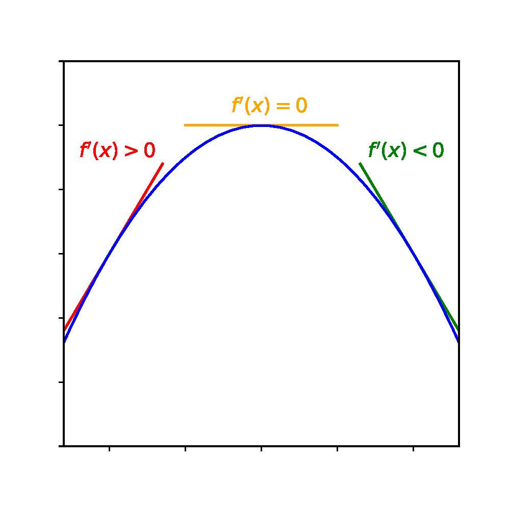

## 極値

関数$f(x)$の導関数$f'(x)$がちょうどゼロで、その前後で$f'(x)$の符号が変わるとき、$f(x)$は**極値**を取るという。

**補足**

$f'(x)$がゼロでも、その前後で$f'(x)$の符号が変わらない場合、その点における$f(x)$は極値ではないことに注意せよ。

- 上に凸となっている極値は**極大値**
- 下に凸となっている極値は**極小値**

極値判定は、

- グラフを描く。
- $f''(x)$のの正負を見る。

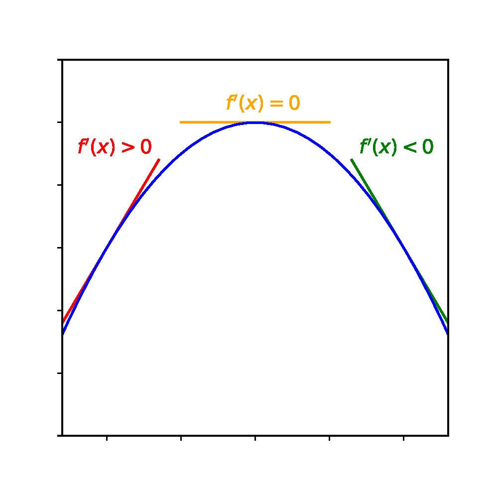

**2階導関数の条件（二階の条件）**

$$\begin{align*}
\left\{
\begin{aligned}
f'(x_0) &= 0 \\
f''(x_0) &< 0
\end{aligned} \right.
\Longrightarrow \text{$f(x)$は$x=x_0$で極大値$f(x_0)$をとる。} \\
\left\{
\begin{aligned}
f'(x_1) &= 0 \\
f''(x_1) &> 0
\end{aligned} \right.
\Longrightarrow \text{$f(x)$は$x=x_1$で極小値$f(x_1)$をとる。}
\end{align*}$$

## 極値に関する注意

「極大だから最大」あるいは「極小だから最小」とはならないことに注意せよ。

逆もまた然りで、「最小だから極小」、「最大だから極大」ともならない。

関数の微分の値について、
$$f''(x_0) = 0$$
となるとき、$(x_0,f(x_0))$は**変曲点**といわれる。

関数は

- $f''(x)<0$のとき上に凸の形状
- $f''(x)>0$のとき下に凸の形状

変曲点はちょうど上に凸と下に凸が変わる点を表している。

## 多変数関数の微分

多変数関数についても微分を行うことができる。 変数として$x,y$を持つ2変数関数
$$f(x,y)$$
が与えられたとする。

これを$x$について微分するとき、もう一つの変数$y$については固定されているものと考えて微分を行うことを、**偏微分**という。

いま、$f(x,y)$を$x$について偏微分したものを、
$$\frac{\partial f(x,y)}{\partial x},\hspace{12pt} \frac{\partial}{\partial x} f(x,y),\hspace{12pt} f_x(x,y)$$
などと書く。

**偏微分の例**

例えば、関数$f(x,y)=x^2 + 2 x y +y^3$を$x$について偏微分すると、
$$\frac{\partial f(x,y)}{\partial x} = 2 x + 2 y$$
となる。 また、$y$について偏微分すると、
$$\frac{\partial f(x,y)}{\partial y} = 2 x + 3 y^2$$
と計算することができる。

これは変数が2変数についての場合のみではなく、一般に何変数の関数でも偏微分は可能である。

## テイラー展開

関数には次のような非常に不思議な性質がある。
$$\begin{aligned}
f(x) &= f(x_0) + \frac{f'(x_0)}{1} (x - x_0) + \frac{f''(x_0)}{1 \cdot 2} (x-x_0)^2 + \cdots \\
&= \sum_{n=0}^{\infty} \frac{f^{(n)} (x_0)}{n!} (x-x_0)^n,
\end{aligned} \label{eq:taylor}$$
これを、$x=x_0$まわりの{テイラー展開}と呼ぶ。

ちなみに、“$!$”は**階乗**という演算子で、
$$\begin{aligned}
n! &\equiv 1 \times 2 \times \cdots \times (n-1) \times n, \\
0! &\equiv 1,
\end{aligned}$$
と定義されている。

## テイラー展開の例

いま、適当に定めた関数
$$f(x) = x^5 - 5x^4 - 9x^2 - 12x + e^{1.2x}$$
を$x=3$においてテイラー展開する。

第$N$項までで近似をするとしよう：
$$f(x) \approx \sum_{n=0}^{N} \frac{f^{(n)} (x_0)}{n!} (x-x_0)^n$$

**f(x)の形状**

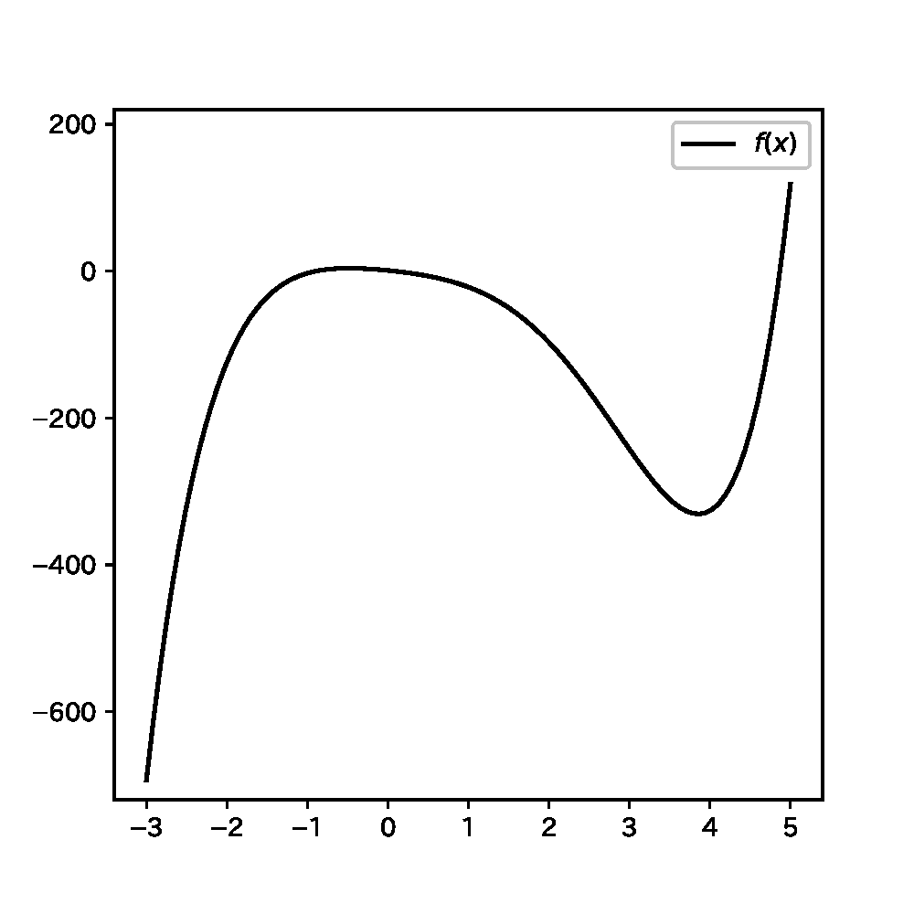

**x=3付近でのテイラー展開**

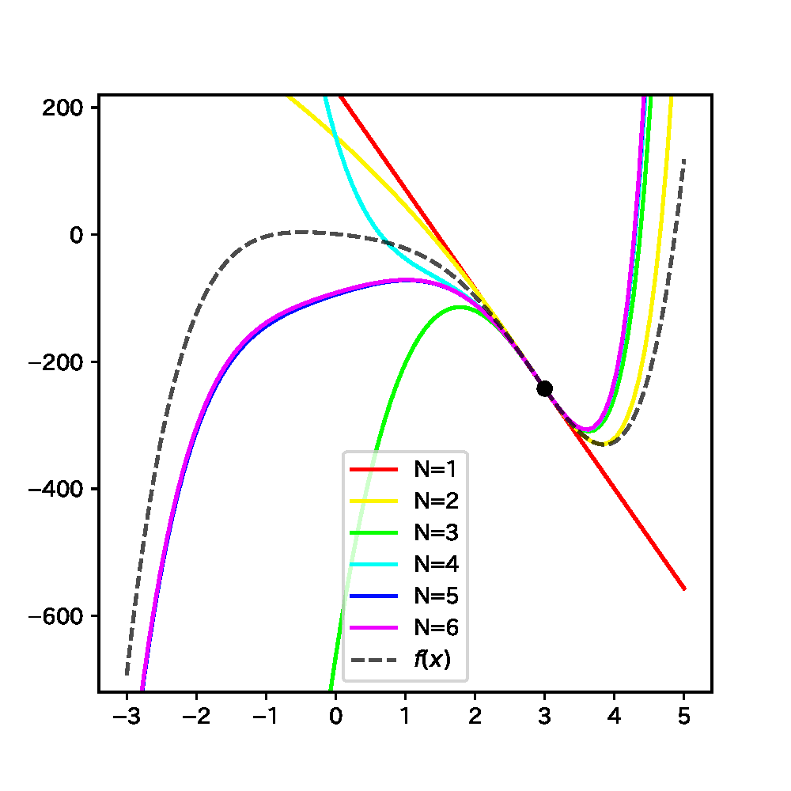

## 関数の一次近似

さて、テイラー展開による近似において$N=1$で近似を行うと、
$$f(x) \approx f(x_0) + f'(x_0) (x - x_0)$$
となる。 これを、関数の**一次近似**という。

- $x=x_0$から離れるほど、$f(x)$とのかい離は大きくなってゆく。
- $x=x_0$と非常に近い場所については、$f(x)$とのかい離はほとんどない。

## 微分可能な関数

関数がある区間で**連続**かつ**なめらか**であるとき、その関数はその区間で**微分可能**という。

**連続性**

ある区間（あるいは点）で関数が**連続**であるとは、直観的には関数がその区間（点）において途切れずにつながっていることを意味する。

対して、ある点において関数が不連続であるとは、ある点において関数がジャンプすることを意味している。

例えば、次の関数$f$は$x=0$において不連続である。
$$f(x) = \left\{ \begin{aligned}
&1 &(x<0) \\
&x &(x \ge 0)
\end{aligned}\right.$$
*関数が連続でない点では微分ができない*。

**なめらかさ**

関数がある点において**なめらか**であるとは、直観的には関数がその点において角ばっていない、あるいはとがっていないことを意味する。

次の関数は$x=0$においてなめらかでない関数$f$である。
$$f(x) = |x|$$
*なめらかでない点では微分ができない*。

# 2 積分

## 積分のアイデア

今、適当な関数$y=f(x)$を考えて、$(x,y)$平面にプロットする。

今、関数$f(x)$のなかのある区間$a \le x \le b$を取り、次の図bに示されるような領域の面積を求めたいとしよう。 ひとまず大まかに面積を近似することを考よう。

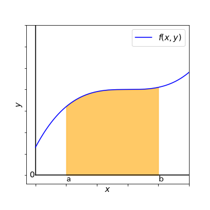

## 区分による近似

$a$から$b$までの区間を5つに区切ると、この時、面積は5つの長方形の和として表される。

各長方形の横の長さは、
$$\frac{a-b}{5} \equiv \Delta x$$
となっている。 そして、各長方形の縦の長さは、
$$f(x_1), f(x_2), f(x_3), f(x_4), f(x_5),$$
なので、求めたい面積の近似値は、
$$\sum_{n=1}^{5} f(x_n) \Delta x$$
とすることができる。

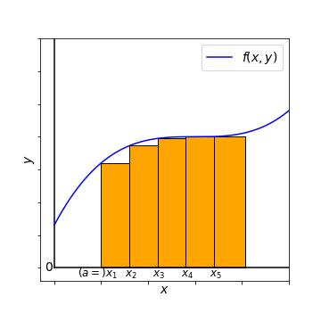

## 区分を増やす

$a$から$b$までの区間をより細かく分割してみよう。

- 分割を増やすほど、もともと求めたかった面積との誤差も小さくなっていく。
- 分割を非常に多くする場合には、求めたい面積と等しくなるとみなすことができるはず。

**n=10**

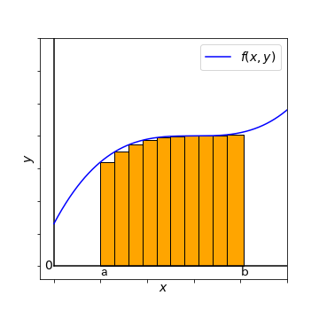

**n=50**

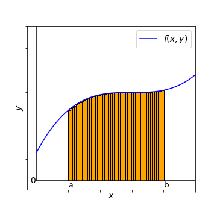

## 面積の近似へ

区間$a$から$b$を$N$分割するとすれば、面積は
$$\sum_{n=1}^N f(x_n) \Delta x$$
で近似できるので、分割が非常に多いときは$N \to \infty$とすればよい。

- $N \to \infty$のとき、分割された1区間の横の長さ$\Delta x$は非常に小さくなる。
  - この時は1区間の横の長さを$dx$と表記する。

## 積分を定義する

関数$f(x)$の区間$a$から$b$における**積分**を
$$\int_a^b f(x) dx \equiv \lim_{N \to \infty} \sum_{n=1}^N f(x_n) \Delta x$$
と定義する。

定義からもわかる通り、積分は関数（とその変数の軸）がつくる領域の面積であると理解することができる。

区間の指定がある積分を**定積分**と呼ぶ。

## 積分区間の分割

積分については、区間の分割ができる。

$a$から$b$までの区間に適当な$c$を取ると、
$$\int_a^b f(x) dx = \int_a^c f(x) dx + \int_c^b f(x) dx$$
であることがわかる。

計算するうえでは、適当な部分で積分しやすいように句切ることが許されている。

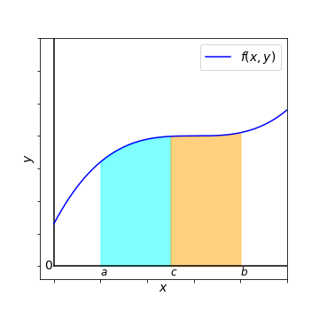

## 原始関数

積分は、微分の逆の演算になっている。 ある関数$F(x)$を考えて、その関数を微分したものを、$f(x)$であるとしよう。 つまり、
$$\frac{d F(x)}{dx} = f(x)$$
となっている。 この時の$F(x)$を$f(x)$の**原始関数**と呼ぶ。 具体的な計算でこの関係性を追ってみよう。

## 最も単純な原子関数を微分する

今、原始関数として、
$$F(x) = x^2$$
という関数を考えてみよう。

これを$x$で微分して$f(x)$を求めると、
$$f(x) = \frac{d F(x)}{dx} = 2x$$
である。 つまり、$f(x) = 2 x$の原始関数の一つは
$$F(x) = x^2$$
である。

## 無数の原始関数

定数$C$を用いて、
$$G(x) = F(x) + C = x^2 + C$$
を新たに定義しよう。

実は$G(x)$を$x$で微分すれば、
$$\frac{d G(x)}{dx} = 2x =f(x)$$
なので、$G(x)$も$f(x)$の原始関数の一つ。

- 定数部分（$C$）は、どんな数も入りうる。
- ゆえに$f(x)$の原始関数$G(x)$は無数に存在する。

## 不定積分

最も簡単な原子関数は、定数項がない次の形。
$$F(x) = x^2$$
これをベースに、積分を次のように定義する。
$$\begin{aligned}
\int f(x) dx = \int 2x dx &= x^2 + C = F(x) + C \nonumber \\
\Longleftrightarrow \int f(x) dx &= F(x) + C
\end{aligned}$$
今、この積分区間は定まっていない。

- このような積分を**不定積分**とよび、定数$C$を**積分定数**と呼ぶ。
- 不定積分には積分定数$C$が必ずついてくることに注意せよ。

## 積分の公式

積分は微分の逆の演算であるため、積分の計算においては微分の公式の逆を使えばよい。

ここでは、以下に示すのみに留める。

**$x^a$の積分**

$$\int x^a dx = \frac{1}{a+1} x^{a+1} + C$$

**指数関数$e^x$の積分**

$$\int e^x dx = e^x + C$$

**$\frac{1}{x}$の積分**

$$\int f(x) dx = \int \frac{1}{x} dx = \log x + C$$

**$\frac{g'(x)}{g(x)}$の積分**

$$\int \frac{g'(x)}{g(x)} dx = \log [g(x)] + C$$

## 積分の線形性

微分と同様に、積分の計算にも*線形性*が成り立つ。

つまり、ある実数$\lambda$および、関数$f(x),g(x)$について
$$\begin{align*}
\int \lambda f(x) dx &= \lambda \int f(x) dx \\
\int [f(x) + g(x)] dx &= \int f(x) dx + \int g(x) dx
\end{align*}$$
が成立する。

これは後に出てくる定積分においても成立する。

## 定積分

積分区間が決まっていない不定積分に対して、積分区間が定まっているものが**定積分**である。 原始関数が$F(x)$である関数$f(x)$の$a \le x \le b$における定積分は、
$$\int_a^b f(x) dx$$
と表される。

定積分の値を求めるためには$f(x)$の原始関数$F(x)$を用いて、
$$\int_a^b f(x) dx = [F(b) + C] - [F(a) + C] = F(b) - F(a)$$
と計算できる。

1. $f(x)$の原始関数のうち、定数項のないもの$F(x)$を計算する、
2. $F(x)$に$x=a,b$を代入し、$F(b)-F(a)$を計算する。

定積分では積分定数$C$がちょうど消える。

## 微積分学の基本定理

$a,b>0$を定数、$F(x)$を関数$f(x)$の原始関数とする。 このとき、次の法則を微積分学の基本定理という。

**微積分学の基本定理**

$$\begin{aligned}
\frac{d}{dx} \left( \int_a^x f(y) dy \right) &= f(x) \\
\int_a^b f(x) dx &= F(b) - F(a)
\end{aligned}$$

## 広義積分

積分区間は実数のみではなく、$\infty$や$-\infty$を取ることもできる。

このような$\pm \infty$を積分区間に含むような積分を、**広義積分**と呼ぶ。

広義積分では、積分値が有限値を取る場合と、発散する場合が存在する。

**広義積分の例**

$$\int_0^{\infty} e^{-x} dx$$
は広義積分の一つである。 これは、次のように計算できる。
$$\begin{aligned}
\int_0^{\infty} e^{-x} dx &= \int_{0}^{\infty} [- e^{-x}]' dx \\
&= [- e^{-x}]_{0}^{\infty} \\
&= [ - \lim_{x \to \infty} e^{-x} + e^{0}] \\
&= 1
\end{aligned}$$

## 部分積分

積の微分法
$$\frac{d}{dx} \{f(x)g(x)\} = f'(x) g(x) + f(x) g'(x)$$
の両辺を積分して整理すると、
$$\int f'(x) g(x) dx = f(x) g(x) - \int f(x) g'(x) dx$$
という関係式が得られる。 これを**部分積分の公式**という。

- 定積分、不定積分の両方に適用できる。

**部分積分の例**

例えば、対数関数$f(x) = \log x$の$1 \le x \le e$区間における積分値を計算してみよう。
$$\begin{aligned}
\int_1^e \log x dx &= \int_1^e \left\{ x \right\}' \log x dx\\
&= \left[ x \log x \right]_1^e - \int_1^e x \{ \log x \}' dx \\
&= [e \log e - 1 \log 1] - \int_1^e x \left( \frac{1}{x} \right) dx \\
&= e - \int_1^e (1) dx \\
&= e - \left[ x \right]_1^e \\
&= e - [ e - 1] \\
&= 1
\end{aligned}$$

## 置換積分

積分おいては、変数の置きかえをすることができる。
$$\int f(x) dx$$
を計算したいとしよう。 $x = g(y)$と置き換えられるとき、 $\frac{dx}{dy} = \frac{dg(y)}{dy}$ なので、
$$dx = \frac{dg(y)}{dy} \cdot dy$$

これを用いて置き換えをすれば、
$$\int f(x) dx = \int \left[ f(g(y)) \frac{dg(y)}{dy} \right] dy$$
として、$y$についての積分を$x$についての積分として書きかえることができる。

このように変数を置き換えて積分する方法を**置換積分**という。

**置換積分の例**

**不定積分**

関数$z(x) = 2x (x^2 + 6)$を不定積分する。
$$\int z(x) dx = \int 2 x (x^2 + 6) dx$$
今、$x^2+6 = y$と置く。すると、
$$\begin{aligned}
\int z(x) dx &= \int 2 x (x^2 + 6) dx \\
&= \int 2x y dx
\end{aligned}$$
ここで、
$$\frac{dy}{dx} = 2x$$
なので、
$$\begin{aligned}
\int z(x) dx &= \int 2x y dx \\
&= \int y \frac{dy}{dx} dx \\
&= \int y dy \\
&= \frac{1}{2} y^2 +C \\
&= \frac{1}{2} (x^2 + 6)^2 +C \hspace{12pt} \because y = (x^2 + 6)
\end{aligned}$$
と、計算できた。 これを$x$で微分すれば$z(x)$が導出できることを確認できる。

**定積分**

*定積分の場合は変数を置き換えたときに積分区間も置きかえる*必要がある。

関数$z(x) = 2x (x^2 + 6)$を$0 \le x \le 10$区間で定積分する。

$$\int z(x) dx = \int 2 x (x^2 + 6) dx$$
今、$x^2+6 = y$と置く。すると、
$$\begin{aligned}
\int z(x) dx &= \int 2 x (x^2 + 6) dx \\
&= \int 2x y dx
\end{aligned}$$
ここで、
$$\frac{dy}{dx} = 2x$$
なので、

いま、積分区間を$dx$から$dy$に置き換える際に、$y = (x^2 + 6)$を用いて、$0 \le x \le 10$の間で$y$が取る値を計算する必要がある。

これは$y$の式に$x$の区間を代入すれば求めることができるので、
$$\begin{aligned}
0^2 + 6 &= 6 \\
10^2 + 6 &= 106,
\end{aligned}$$
したがって、
$$6 \le y \le 106$$

置きかえに注意して計算をすると、
$$\begin{aligned}
\int_0^{10} z(x) dx &= \int_{0}^{10} 2x y dx \\
&= \int_6^{106} y \frac{dy}{dx} dx \hspace{12pt} (\text{ここで区間を置きかえ}) \\
&= \int_{6}^{106} y dy \\
&= \left[ \frac{1}{2} y^2 \right]_6^{106} \\
&= \frac{1}{2} [106^2 - 6^2] \\
&= \frac{1}{2} [11236^2 - 36^2] \\
&= \frac{11200}{2} \\
&= 5600
\end{aligned}$$

置換積分を用いないで計算する場合、
$$\begin{aligned}
\int_0^{10} 2x (x^2 +6) dx &= \int_0^{10} 2x (x^2 +6) dx \\
&= \int_0^{10} (2 x^3 + 12 x) dx \\
&= \left[ 2 \left(\frac{1}{4} x^4\right) + 12 \left( \frac{1}{2} x^2 \right) \right]_0^{10} \\
&= \left[ \frac{1}{2} x^4 + 6 x^2 \right]_0^{10} \\
&= \frac{1}{2} (10)^4 + 6 (10)^2 \\
&= 5600
\end{aligned}$$
となり、当然解答は一致する。